# 課堂練習 2019_10_02

Y.T Lin

2019/10/2

```r
library(dplyr); library(stringr); library(ggplot2); library(plotly); library(lubridate); library(readr); library(tidyr); library(showtext)

#font_add("QYuan","cwTeXQYuan-Medium.ttf") # 新增字體
showtext_auto(enable=TRUE) #啟用字體
theme_set(theme_classic())
knitr::opts_chunk$set(out.width='80%', fig.asp=.75, fig.align='center', fig.showtext=T)
```

Inclass codes for data visualiztion 2019_10_02 .

Last week, we talked about some basics for the ggplot2 package and drawed a few simple plots for the touch of it.

## HW Stipulations

To hand in the weekly assignment, you will need to follow the templates set in “每周一圖作業.RMD”.If you have a distinctive CSV file rather than a URL code line in the code script, the CSV file will have to the turned in as well. The stand alone CSV data file will have to be named “graphData.CSV”.

The prerequirements for the graphing homework, you will first perform a simple data cleaning. The preferred dataset class is “LIST”. Other than the maiin course of graphing, you are required to write a short block of explanation to construe the data you are to graph. The context must expatiate the data itself and also the phenomenon it represents.The above info is demonstrated in the “每周一圖作業.RMD”.

The weekly assignment must be turned in with the R markdown file (RMD) along with your graphData file (that is, if you have one). If you have multiple data files amerlated for graphing purpose, you must first combine your data BeEFORE the data cleaning process AND transform it in to a “DATAFRAME” then export it into a “RDA” file. Your graphData must only contain a single file, also, the RDA file only contains a single dataset. The code block tags are not to be changed, EVER.

## Ch3. Aesthetic Scales

```r
library(grDevices) # 不同顏色模型代碼的呈現及轉換
library(scales) # show_col()螢幕立即顯示顏色
```

```r
library(colorspace) # 調色盤選擇及ggplot應用工具
library(shinyjs) # 支援套件
rgb(0,0,1) # color code returns "#0000FF"
```

```
## [1] "#0000FF"
```

```r
rgb(0.5, 0, 0.7) # color code returns "#8000B3"
```

```
## [1] "#8000B3"
```

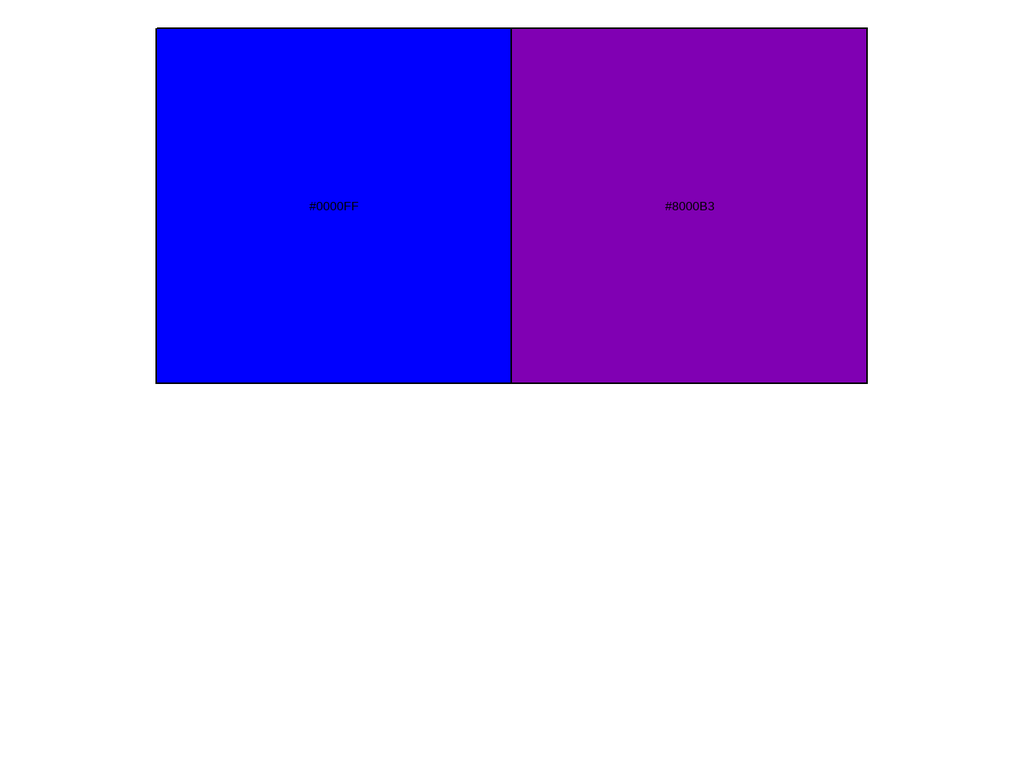

```r
scales::show_col(c(rgb(0,0,1),rgb(0.5,0,0.7)))
```

```r
  # show what the color code color is
```

```r
 # hsv(Hue = , Saturation = , Value = )
scales::show_col(
  c(
    hsv(30/360,0,0),hsv(30/360,0.5,0),hsv(30/360,1,0), # (,,lightness=0) 全暗
    hsv(30/360,0,0.5),hsv(30/360,0.5,0.5),hsv(30/360,1,0.5), # (,,lightness=0.5)
    hsv(30/360,0,1),hsv(30/360,0.5,1),hsv(30/360,1,1) # (,,lightness=1) 全亮
  )
)
```

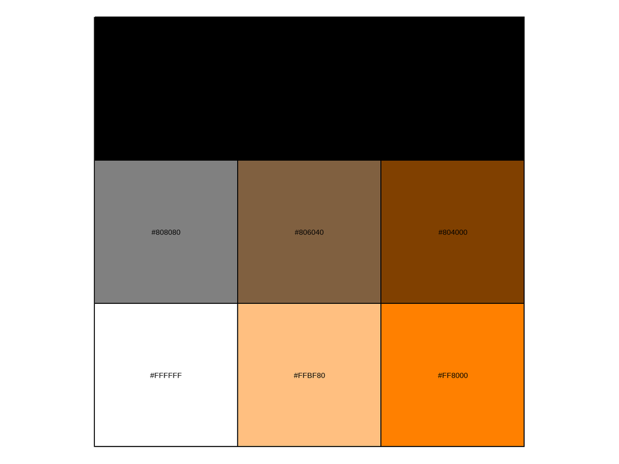

```r
colorspace::choose_color() # choose the desired color and returns a color code
```

## Palette

```r
colorspace::choose_palette(gui = "shiny")

# After we finish the color selection, we will have to click on the "EXPORT" button, export to R, then copy the codelines under the title "Register custom color palette"

# Remember to change the name of the collection of colors "Custom-Palette" into something else.
# example shown in the below ggplot2 apply
```

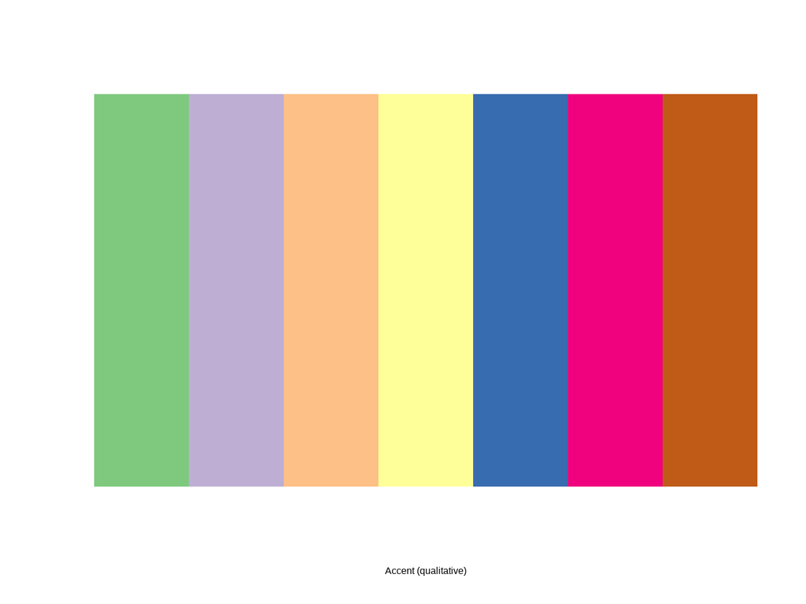

```r
library(RColorBrewer)
display.brewer.pal(7,"Accent")
```

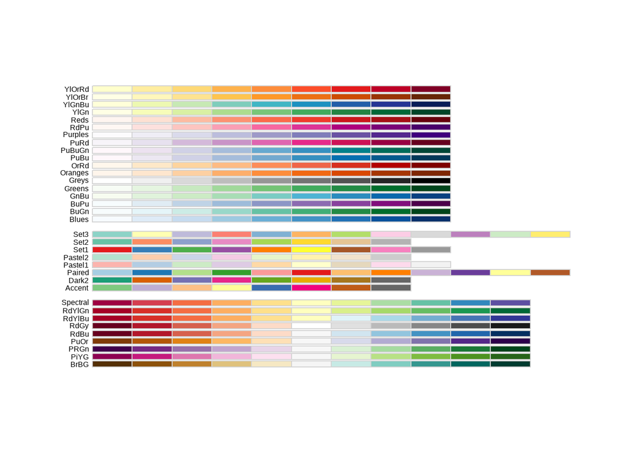

```r
display.brewer.all()
```

For different types of data, the color selection criterion differs. Details are presented in the below code chunks:

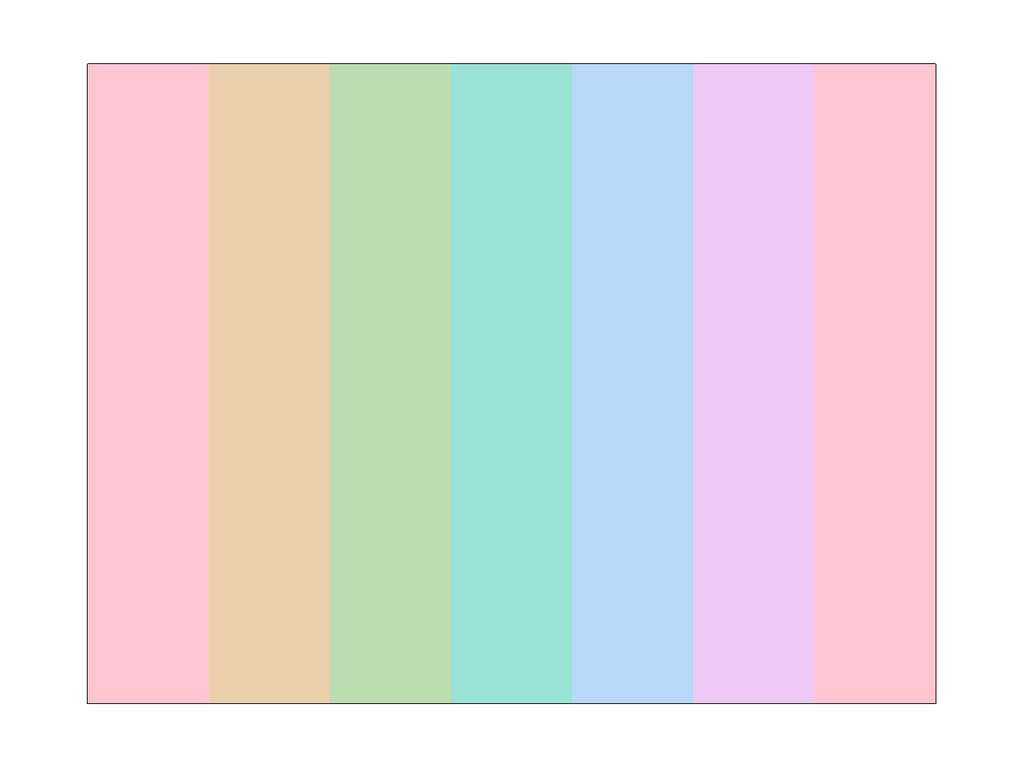

```r
pal_qual <- colorspace::qualitative_hcl(
  n = 7,
  h = c(0, 360), c = 35, l = 85,
  register = "myQualitative"
  )

pal_qual %>% specplot(hcl=F)
```

```r
 # Categorical data requires a discernible color selection
```

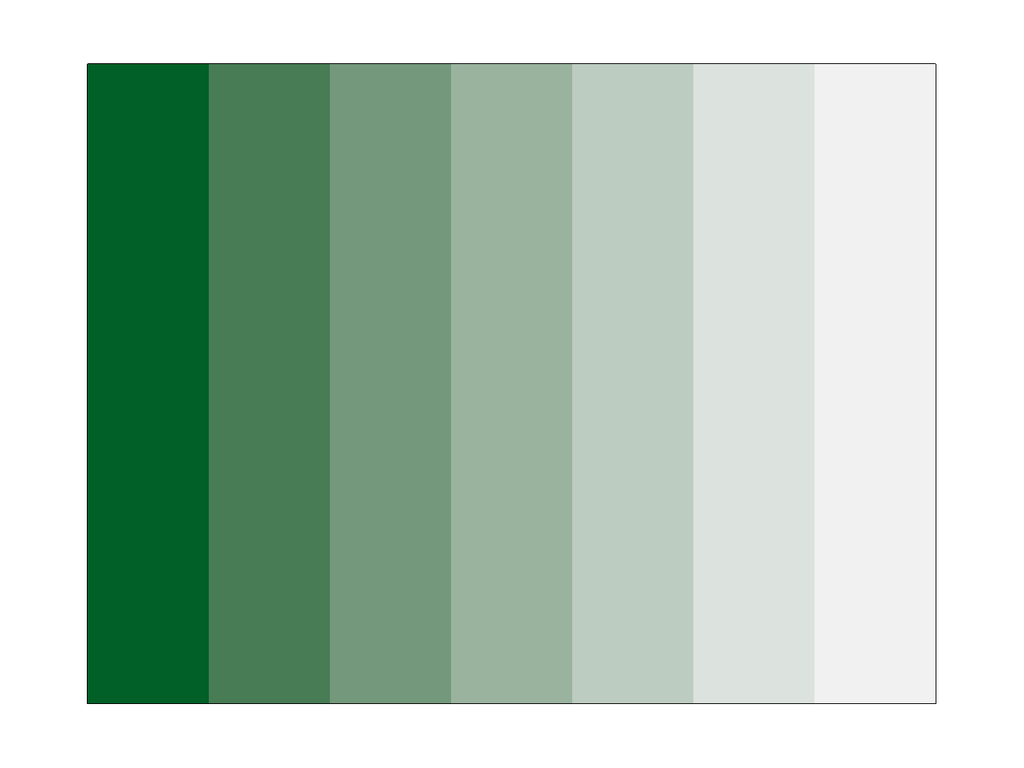

```r
pal_seq <- colorspace::sequential_hcl(
  n = 7,
  h = 135, c = c(45, NA, NA), l = c(35, 95),
  power = 1.3,
  register = "mySequential")

pal_seq %>% specplot(hcl=F)
```

```r
  # Continuous data type requires a selection of colors to show the heirarchical difference between the values.
```

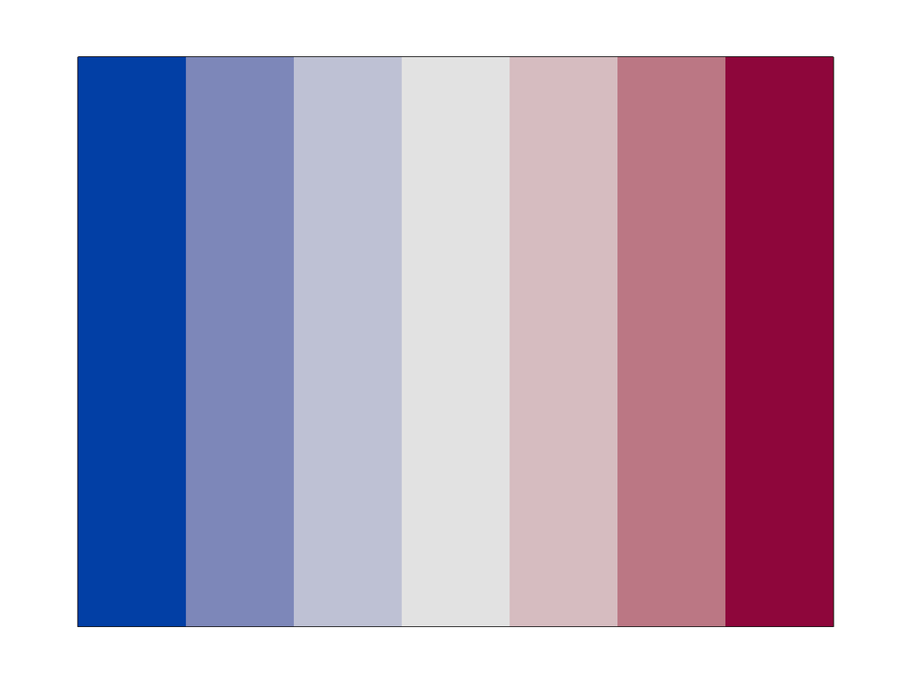

```r
pal_diverge <- colorspace::diverging_hcl(
  n = 7,
  h = c(260, 0), c = 80, l = c(30, 90),
  power = 1.5,
  register = "myDiverge")

pal_diverge %>% specplot(hcl=F)
```

```r
  # Diverging data requires to emphasize the bilateral differences. A set of contrasting color choice is preferred.
```

## CH3.1.2 GGPLOT Application

Now, we get back to the ggplot2 package. In this section, we strive to apply the former color selection process onto the graphical representation.

We start by making a example dataframe:

```r
data.frame(
  x1 = factor(sample(c(1L,2L,3L),100,replace=T)),
  x2 = runif(100),
  y = runif(100),
  z1 = rnorm(100),
  z2 = factor(sample(letters[1:4],100,replace=T))
) -> df_example
```

Then, we draw a basic boxplot

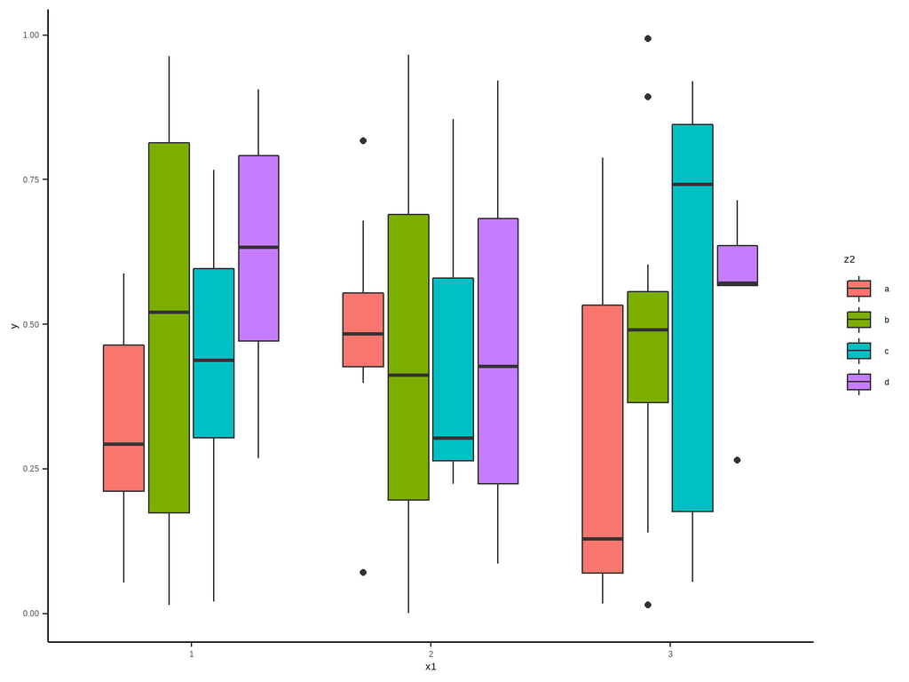

```r
basicboxplot <- df_example %>%
  ggplot(aes(x = x1, y = y, fill = z2)) +
  geom_boxplot() #fill can change the filling of the plot

basicboxplot
```

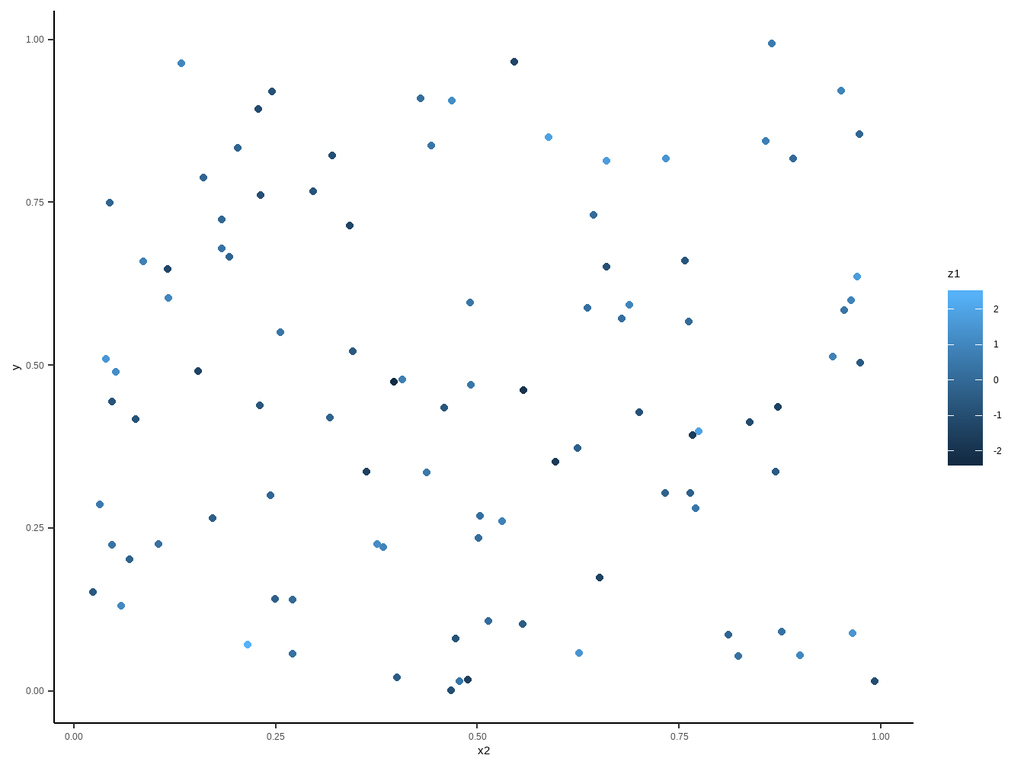

```r
basicScatterplot <- df_example %>%
  ggplot(aes(x = x2, y = y, color = z1)) +
  geom_point() #fill can change the filling of the plot

basicScatterplot
```

```r
 colorspace::choose_palette(gui = "shiny")

colorspace::qualitative_hcl(n = 7, h = c(0, 360), c = 35, l = 85, register = "exampleforclass")

basicboxplot +
  scale_fill_discrete_qualitative(palette = "exampleforclass", nmax = 5)

colorspace::sequential_hcl(n = 17, h = 360, c = c(100, NA, NA), l = c(18, 98), power = 1.3, register = "exclass2")

basicScatterplot +
  scale_color_continuous_sequential(palette = "exclass2")
```

The “RColorBrewer” can also be applied. You might want to check the color codes for different brewer palette.

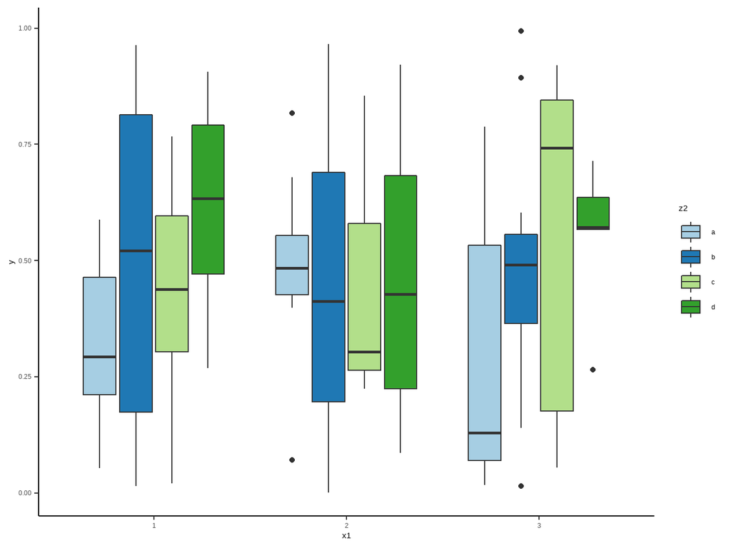

```r
basicboxplot +
  scale_fill_brewer(type = "qual", palette = 3)
```

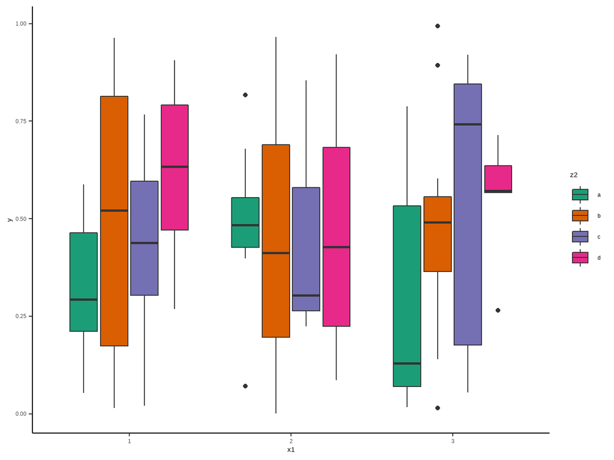

```r
basicboxplot +
  scale_fill_brewer(palette = "Dark2")
```

```r
# scale_fill_brewer and scale_color_brewer are for discrete values ONLY
```

## 3.4 Practice

```r
library(readr)
disposableIncome <- read_csv("https://www.dropbox.com/s/z80sbjw94cjex8x/disposableIncome.csv?dl=1",
locale = locale(encoding = "BIG5"), skip = 4)

disposableIncome_gather <- disposableIncome %>%
  tidyr::gather(dplyr::contains("可支配所得"), key = "類別", value = "可支配所得")  %>%
  mutate("年" = as.integer(X1)) %>% slice(33:43)
# Unfinished, needs refinement


disposableIncome_gather %>%
  ggplot( aes( x = X1, y = `可支配所得`, color = 類別) ) +
  geom_path()
```